# Gasoline Prices in Mexico

Fuel Price Fluctuations, A Constant Concern

Author

Jesus L. Monroy

Published

Feb, 2025

Abstract

Gasoline prices in Mexico are a complex issue influenced by various factors. In this article we examine the gasoline prices in the 32 States that constitute Mexico and also their differences in cost, sale price and profits. Challenges remain in stabilizing prices and mitigating the impact on consumers and the economy.

[figure not shown]

Figure 1: Gas Prices in Mexico Report

# Overview

### Current Situation

- **Rising Prices**

Despite government efforts to stabilize fuel costs, gasoline prices in Mexico have been on the rise. Some estimates suggest prices could reach MX$30 per liter during 2025.

- **Regional Variations**

- **Government Intervention**

The government has implemented measures like a price cap of MX$24 per liter for regular gasoline and has been working to stabilize fuel prices. However, these efforts have faced challenges.

### Factors Affecting Prices

- **Global Oil Prices**

International oil prices play a significant role in determining gasoline prices in Mexico.

- **Government Policies**

Taxes, subsidies, and regulations implemented by the Mexican government influence fuel prices.

- **Economic Conditions**

Inflation, exchange rates, and other economic factors can impact gasoline prices.

### Challenges and Concerns

- **Impact on Low-Income Families**

Rising gasoline prices put a strain on low-income households, affecting their daily expenses and overall economic well-being.

- **Economic Impact**

Increased fuel costs can have a ripple effect across various sectors of the economy, potentially leading to inflation and affecting businesses.

- **Government Promises**

The government’s promises to keep gasoline prices low have been met with skepticism, as prices continue to climb.

### Table overview

The table below provides a preview of the working dataset, offering a glimpse into the structure and type of data being utilized.

| state | municipality | gasoline_cost | sale_price | profit | profit% |
| --- | --- | --- | --- | --- | --- |
| CHIHUAHUA | JUAREZ | $21.63 | $23.31 | $1.68 | 7.76% |
| COAHUILA DE ZARAGOZA | SABINAS | $21.63 | $23.31 | $1.68 | 7.76% |
| COAHUILA DE ZARAGOZA | TORREON | $21.63 | $23.31 | $1.68 | 7.76% |
| DURANGO | GOMEZ PALACIO | $21.63 | $23.31 | $1.68 | 7.76% |
| NUEVO LEON | ABASOLO | $21.63 | $23.31 | $1.68 | 7.76% |

Table 1: Dataset preview

## Top 05 States with highest gasoline prices

The following table presents a snapshot of the States with highest gasoline prices in Mexico.

| state | gasoline_cost | sale_price | profit | profit% |
| --- | --- | --- | --- | --- |
| QUINTANA ROO | $21.46 | $24.80 | $3.34 | 15.55% |
| YUCATAN | $21.46 | $24.79 | $3.33 | 15.52% |
| NAYARIT | $22.54 | $24.76 | $2.23 | 9.90% |
| GUERRERO | $22.37 | $24.76 | $2.39 | 10.67% |
| SINALOA | $22.36 | $24.72 | $2.36 | 10.59% |

Table 2: Top 05 States with highest prices

## Top 05 States with lowest gasoline prices

The following table presents a snapshot of the States with lowest gasoline prices in Mexico.

| state | gasoline_cost | sale_price | profit | profit% |
| --- | --- | --- | --- | --- |
| TAMAULIPAS | $21.22 | $23.10 | $1.87 | 8.79% |
| COAHUILA DE ZARAGOZA | $22.25 | $23.12 | $0.87 | 4.01% |
| CHIHUAHUA | $21.47 | $23.36 | $1.89 | 8.90% |
| NUEVO LEON | $21.41 | $23.40 | $1.99 | 9.32% |
| VERACRUZ DE IGNACIO DE LA LLAVE | $21.59 | $23.44 | $1.86 | 8.62% |

Table 3: Top 05 States with lowest prices

## Top 05 Municipalities with highest gasoline prices

The following table presents a snapshot of the Municipalities with highest gasoline prices in Mexico.

| mun_state | gasoline_cost | sale_price | profit | profit% |
| --- | --- | --- | --- | --- |
| NUEVA ITALIA, MICHOACAN DE OCAMPO | $22.52 | $25.17 | $2.65 | 11.78% |
| ZIRACUARETIRO, MICHOACAN DE OCAMPO | $22.52 | $25.17 | $2.65 | 11.78% |
| GABRIEL ZAMORA, MICHOACAN DE OCAMPO | $22.52 | $25.17 | $2.65 | 11.78% |
| HUIRAMBA, MICHOACAN DE OCAMPO | $22.52 | $25.17 | $2.65 | 11.78% |
| NAHUATZEN, MICHOACAN DE OCAMPO | $22.52 | $25.17 | $2.65 | 11.78% |

Table 4: Top 05 Municipalities with highest prices

## Top 05 Municipalities with lowest gasoline prices

The following table presents a snapshot of the Municipalities with lowest gasoline prices in Mexico.

| mun_state | gasoline_cost | sale_price | profit | profit% |
| --- | --- | --- | --- | --- |
| ANAHUAC, NUEVO LEON | $20.57 | $20.74 | $0.17 | 0.84% |
| CD. GUERRERO, TAMAULIPAS | $20.57 | $20.74 | $0.17 | 0.84% |
| LAMPAZOS DE NARANJO, NUEVO LEON | $20.57 | $20.74 | $0.17 | 0.84% |
| ALLENDE, COAHUILA DE ZARAGOZA | $22.59 | $21.02 | $-1.57 | -6.94% |
| MORELOS, COAHUILA DE ZARAGOZA | $22.59 | $21.02 | $-1.57 | -6.94% |

Table 5: Top 05 Municipalities with lowest prices

# Average Gasoline Price by State

The following chart shows average gasoline prices by State in Mexico.

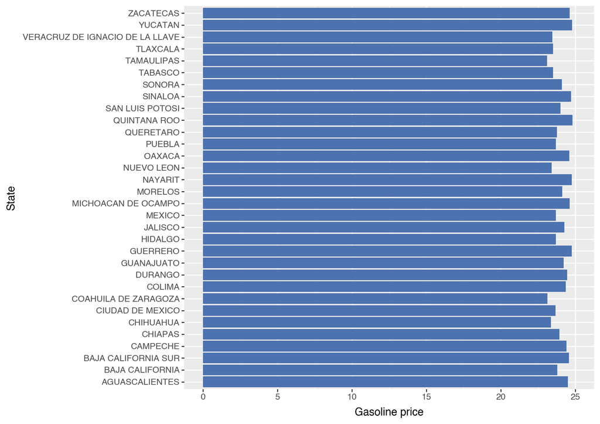

Figure 2: Average Gasoline Prices by State

# Profit by State

The following chart shows average profit by selling gasoline by State in Mexico.

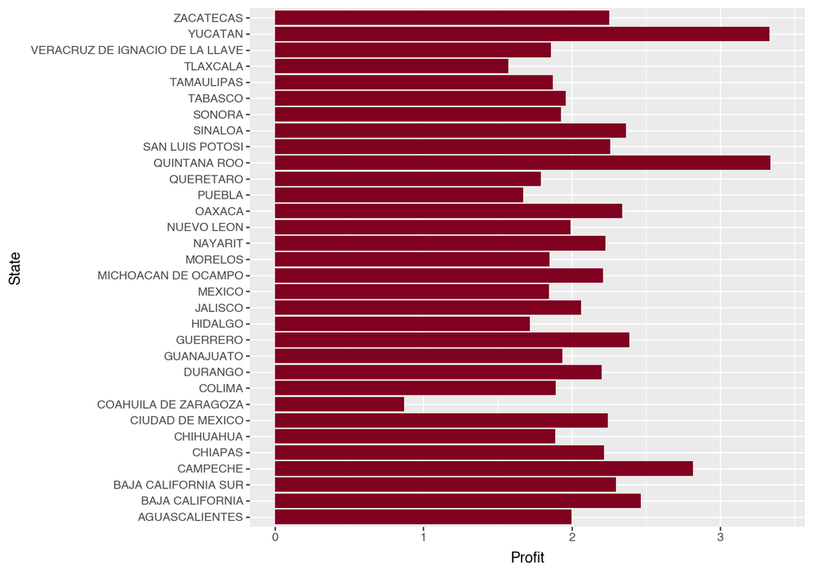

Figure 3: Profit by State

# Dispersion of Gasoline Prices

The following chart shows the dispersion of gasoline prices by State in Mexico.

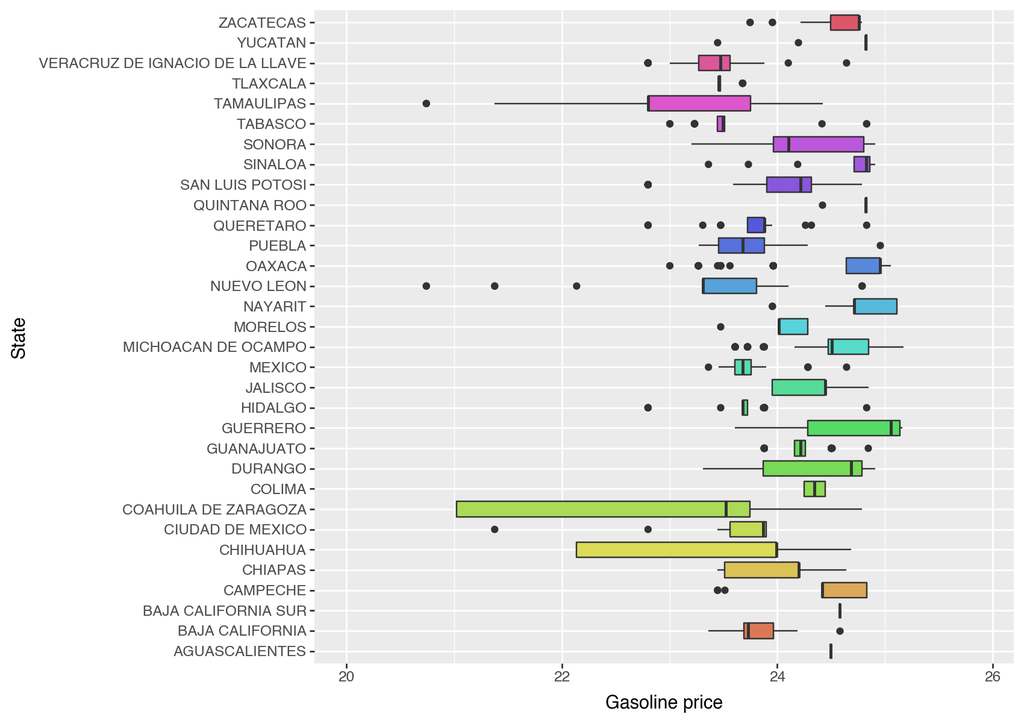

Figure 4: Dispersion of Gasoline Prices by State

# Dispersion of Profits

The following chart shows the dispersion of profit by selling gasoline by State in Mexico.

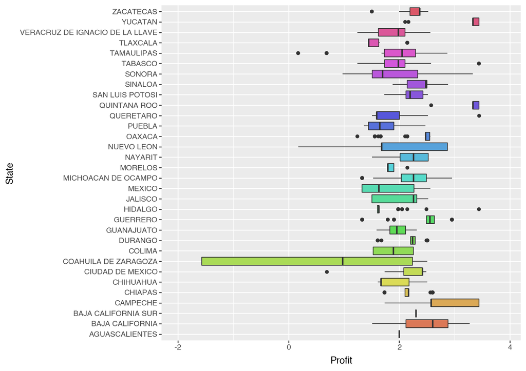

Figure 5: Dispersion of Profits by State

# Geographical Distribution

[interactive chart not shown]

Figure 6: Gasoline Sale Prices by State in Mexico

# Conclusions

In most states, filling a 40-liter car tank costs around $1,000 pesos.

While precise price predictions are difficult, it’s reasonable to expect continued volatility in gasoline prices in Mexico during 2025.

The interplay of global oil markets, government policies, and domestic economic conditions will create a dynamic environment. Consumers should be prepared for potential price fluctuations and consider strategies for managing their fuel expenses.

The energy sector, meanwhile, will be closely watched as Mexico navigates the complex challenges of ensuring affordable and accessible fuel for its population.

The future of gasoline prices in Mexico remains uncertain, but one thing is clear: it will continue to be a topic of significant importance for both consumers and policymakers.

# Contact

**Jesus L. Monroy**

*Economist & Data Scientist*

[Medium](https://medium.com/@jesus_lmonroy) | [Linkedin](https://www.linkedin.com/in/j3sus-lmonroy) | [Twitter](https://www.twitter.com/sqlalchemist)